# Project 3 – Predicting Math 325 Final Exam Scores

Matt Hirschi

## Overview

The goal of this project is to come up with a model that accurately predicts final exam scores in Math 325.

The earlier in the semester that your model can be applied, the more useful it becomes. The goal of the prediction is two-fold. First, it gives the students in the course an accurate prediction of how well they are doing knowledge-wise in the course. Second, it allows the teacher a way to identify students that are struggling early on in hopes of helping them improve their final performance.

## Step 1. Find your Data

Use the `Math325` dataset that is provided (in I-Learn) for this project.

```r
library(tidyverse)
```

```r
library(mosaic)
library(car)
library(janitor)
dat <- read_csv("Math325.csv")
```

## Step 2. Model the Data

Use good model selection strategies to develop a “best” model for predicting the data. Defend your choice of the model with supporting p-values, supporting information criterion (like $R^2_a$, $AIC$, or $BIC$), and useful graphics (like scatterplots, added variable plots and diagnostic plots).

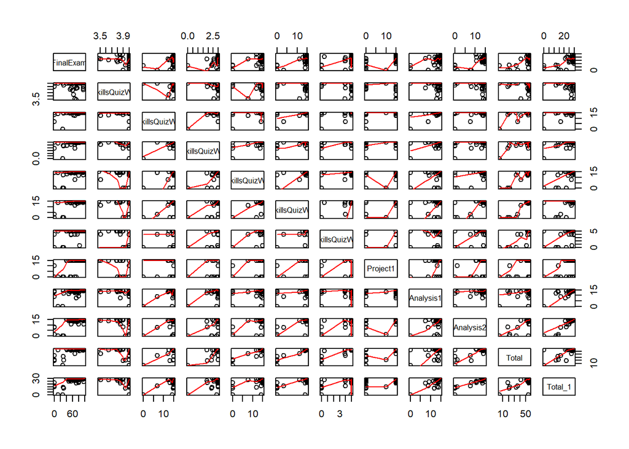

```r
dat1 <- dat %>%
  select(FinalExam, SkillsQuizW1, SkillsQuizW2, SkillsQuizW3,SkillsQuizW4, SkillsQuizW5, SkillsQuizW6,Project1, Analysis1, Analysis2) %>%
  mutate(Total = SkillsQuizW1 + SkillsQuizW2 + SkillsQuizW3 + SkillsQuizW4 + SkillsQuizW5 + SkillsQuizW6) %>%
  mutate(Total_1 = Analysis1 + Analysis2)

pairs(dat1, panel = panel.smooth)
```

```r
#best model I found
model <- lm(FinalExam ~ Total +  I(Total) + Analysis2 + Total:Analysis2 + I(Total^2):Analysis2, data = dat1)
summary(model)
```

```
##
## Call:
## lm(formula = FinalExam ~ Total + I(Total) + Analysis2 + Total:Analysis2 +
##     I(Total^2):Analysis2, data = dat1)
##
## Residuals:
##     Min      1Q  Median      3Q     Max
## -34.159 -10.159   0.921   9.871  38.376
##
## Coefficients: (1 not defined because of singularities)
##                        Estimate Std. Error t value Pr(>|t|)
## (Intercept)           21.361455  13.085930   1.632   0.1073
## Total                  0.017795   0.381461   0.047   0.9629
## I(Total)                     NA         NA      NA       NA
## Analysis2            -12.089499   5.802689  -2.083   0.0410 *
## Total:Analysis2        0.535715   0.263267   2.035   0.0458 *
## Analysis2:I(Total^2)  -0.004615   0.002924  -1.578   0.1192
## ---
## Signif. codes:  0 '***' 0.001 '**' 0.01 '*' 0.05 '.' 0.1 ' ' 1
##
## Residual standard error: 15.41 on 67 degrees of freedom
## Multiple R-squared:  0.5548, Adjusted R-squared:  0.5282
## F-statistic: 20.87 on 4 and 67 DF,  p-value: 3.302e-11
```

```r
model1 <- lm(FinalExam ~ Total + Analysis2 + Total:Analysis2, data = dat1)
summary(model1)
```

```
##
## Call:
## lm(formula = FinalExam ~ Total + Analysis2 + Total:Analysis2,
##     data = dat1)
##
## Residuals:
##     Min      1Q  Median      3Q     Max
## -35.280 -11.280   0.156  10.761  37.258
##
## Coefficients:
##                 Estimate Std. Error t value Pr(>|t|)
## (Intercept)     17.99172   13.05131   1.379  0.17256
## Total            0.09643    0.38232   0.252  0.80162
## Analysis2       -3.77955    2.46501  -1.533  0.12985
## Total:Analysis2  0.12688    0.04744   2.675  0.00936 **
## ---
## Signif. codes:  0 '***' 0.001 '**' 0.01 '*' 0.05 '.' 0.1 ' ' 1
##
## Residual standard error: 15.58 on 68 degrees of freedom
## Multiple R-squared:  0.5382, Adjusted R-squared:  0.5179
## F-statistic: 26.42 on 3 and 68 DF,  p-value: 1.922e-11
```

```r
model2 <- lm(FinalExam ~ SkillsQuizW1 + I(SkillsQuizW1^2) + Analysis2 + SkillsQuizW1:Analysis2 + I(SkillsQuizW1^2):Analysis2, data = dat1)
summary(model2)
```

```
##
## Call:
## lm(formula = FinalExam ~ SkillsQuizW1 + I(SkillsQuizW1^2) + Analysis2 +
##     SkillsQuizW1:Analysis2 + I(SkillsQuizW1^2):Analysis2, data = dat1)
##
## Residuals:
##     Min      1Q  Median      3Q     Max
## -46.280  -9.082   1.576  10.998  40.554
##
## Coefficients:
##                             Estimate Std. Error t value Pr(>|t|)
## (Intercept)                 -9581.04   28967.40  -0.331    0.742
## SkillsQuizW1                 4653.37   14715.06   0.316    0.753
## I(SkillsQuizW1^2)            -563.42    1868.79  -0.301    0.764
## Analysis2                     585.34    1959.87   0.299    0.766
## SkillsQuizW1:Analysis2       -278.54     995.33  -0.280    0.780
## I(SkillsQuizW1^2):Analysis2    33.28     126.38   0.263    0.793
##
## Residual standard error: 17.04 on 66 degrees of freedom
## Multiple R-squared:  0.4642, Adjusted R-squared:  0.4236
## F-statistic: 11.44 on 5 and 66 DF,  p-value: 5.725e-08
```

```r
model3 <- lm(FinalExam ~ Total +  I(Total^2) + Total_1 + Total:Total_1 + I(Total^2):Total_1, data = dat1)
summary(model)
```

[output not shown]

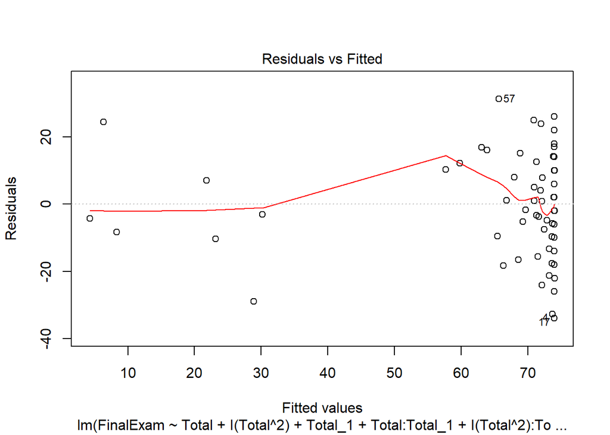

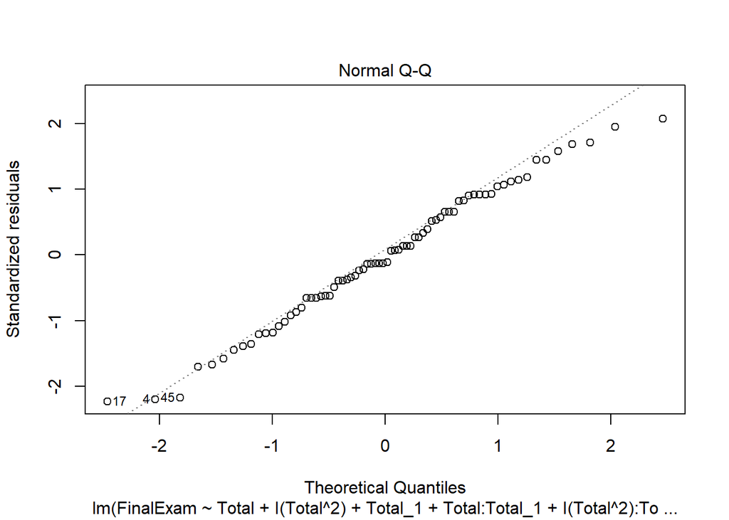

```r
plot(model3, which = 1:2)
```

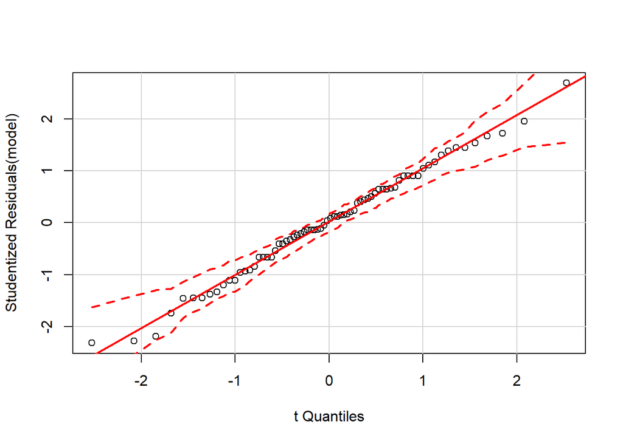

```r
qqPlot(model)
```

## Step 3. Describe your Strategy

Interpret your regression model and describe it in a way that is simple and intuiative.

## Grading

You will be graded on two things.

1. How well you apply the regression principles we have learned thus far this semester. (Think Projects 1 and 2.)
2. How well you interpret your results and describe your “buying and selling” strategy.